# Release Notes for STM32 Cellular Middleware

Copyright © 2022 STMicroelectronics

# Purpose

Overview (RTOS agnostic) of the X-CUBE-CELLULAR (Core of the STM32 Cellular software expansion for STM32Cube)

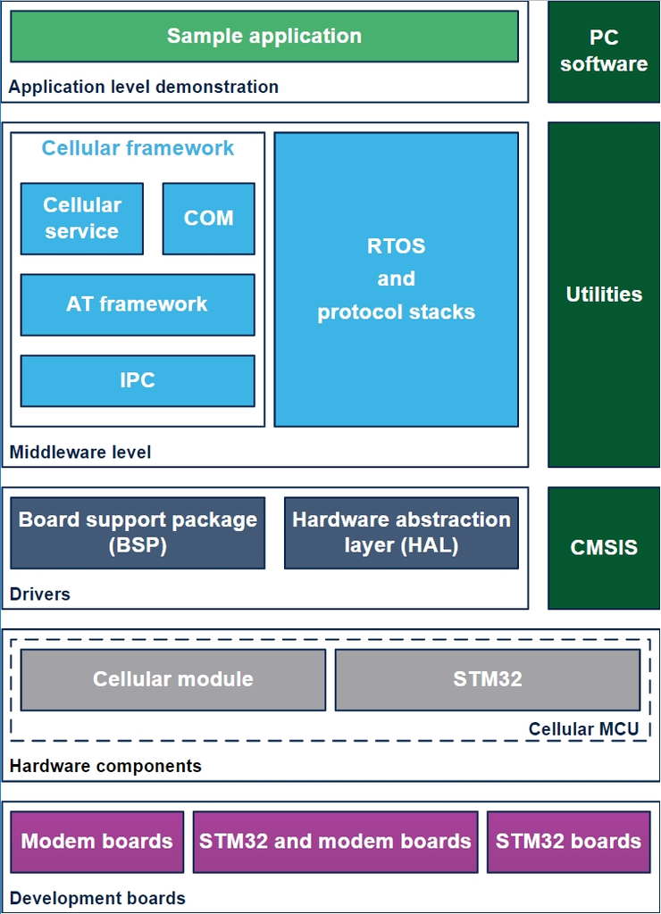

Overview of the X-CUBE-CELLULAR used in Azure RTOS environment.

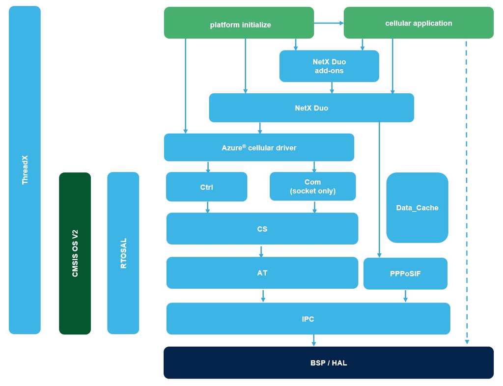

Overview of the X-CUBE-CELLULAR used in FreeRTOS environment.

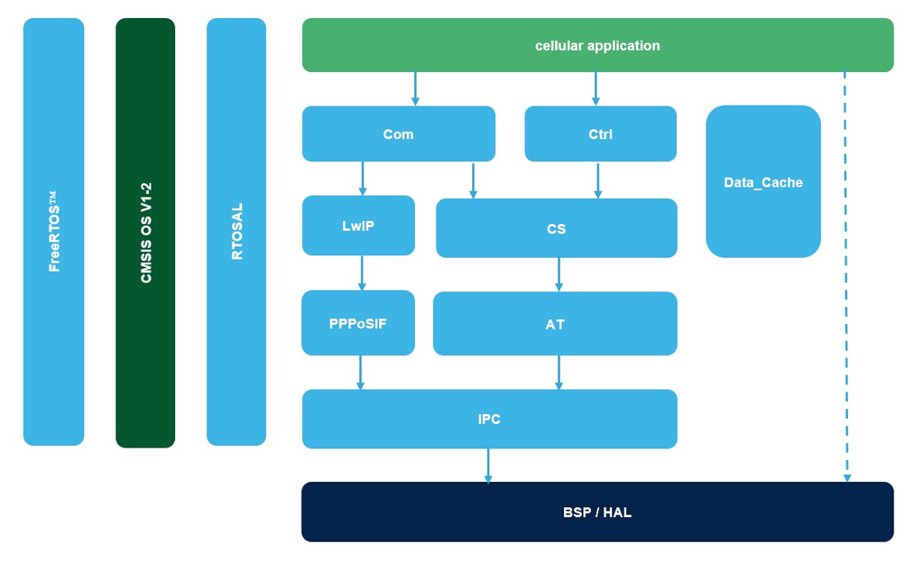

- The Cellular Middleware is the SW stack that allows to drive cellular modems from STM32 MCUs.
- User can choose between IP stack in STM32 (NetX Duo in Azure RTOS or LwIP with FreeRTOS, called STM32 IP) or in modem (called Modem IP mode) thanks to a compiler switch.
- Upper layers APIs are composed of COM (data plane) APIs and Control (Control plane) APIs.
- AT is an AT command handler, it is splitted in 2 parts, core (modem agnostic part, generic) and custom (modem dedicated part, one per modem).
- PPPosIF is the interface for the IP stack (Netx Duo or LwIP) for the STM32-Modem serial interface (through IPC, that abstracts the UART)
- CST/CS is Cellular Service (Task and library) this is the Cellular dynamic part.
- Reminder: The Cellular middleware is compliant with MISRA-C®:2012 with some minor limitations and checked against a static analysis tool to eliminate run-time errors. Reports are available on demand under NDA.
- There is at least one application to use Cellular middleware and it is available for all supported setups.

List of references to user documents:

- [Cellular STMicroelectronics MCU Wiki](https://wiki.st.com/stm32mcu/wiki/Cellular_LTE_CatM_/_NBIoT_overview) - ST Wiki dedicated to MCU, Cellular page
- [DB3582](https://www.st.com/resource/en/data_brief/x-cube-cellular.pdf) - Data Brief of the Cellular connectivity software expansion for STM32Cube

# Update history

**V7.1.0 / 28-Apr-2023**

## Main changes

### Maintenance release and product update

Changes regarding previous versions

- It is a maintenace release
- Directories organization updated (for CubeMX regeneration support)
- Project can be regenerated using CubeMX thanks .ioc and .extSettings files
- .extSettings files are used during CubeMX generation to add Cellular files into IDEs
- FreeRTOS/LwIP is available through a dedicated add-on (not included in the main delivery)

Other improvements

- Quality tools
- SIM slot management
- Modem state mangement
- Cellular MCU Wiki updated

## Bug fixes

- PPP management
- MODEM_RING / EXTI
- RAT selection added to Ctrl API
- Modem CID management

## Known Limitations

- Modem Low Power supported (STM32 low power is not yet demonstrated).
- Modem low power can be enable only with IP stack in modem (not in STM32).
- COM : multi-threads using same socket not supported, for example one thread is wait for receiving data on a socket, another thread cannot send data on the same socket
- COM/AT : Error code returned by the Modem is not reported to the application via socket BSD.
- COM API functions com_send, com_sendto or com_recv, com_recvfrom may block even if application has defined MSG_DONTWAIT. It is due to the nature of AT command/response exchange with Modem.
- Ctrl : Deinit and Stop of platform is not supported
- CellularIoT samples is an application example demonstrating the use of display and sensors of B-L462E-CELL1 board. First line displayed should be the UTC date and time. When data connection is established, with the actual application, Date/Time is requested one time only to a distant server and sometimes the server doesn’t respond to this request; in this case date/time isn’t displayed and treatment continue.
- IPV6 not supported
- TCP server not supported

## HW supported

- See Project Release Note

**V7.0.0 / 28-Feb-2022**

## Main changes

### Maintenance release and product update

This V7.0.0 is a big change regarding previous versions

- Azure RTOS (ThreadX and NextX Duo) has been added to FreeRTOS/LwIP
- FreeRTOS/LwIP is available through a dedicated add-on (not included in the main delivery)
- It uses RTOSAL as before but a new cmsis_os2 has been added, to support ThreadX, to the cmsis_os2 used (for FreeRTOS) in previous deliveries.

Other improvements

- cst targetstate commands renamed into cst modem
- APN automatic selection uses ICCID to support SIM card with Multi-IMSI features
- cst info command, new information is displayed (for debug when traces are deactivated)
- Code refactoring for Cellular Service API (API between CS Task (CST) and AT-Core)
  - The code dedicated to Socket Mode (IP stack in modem) as been put in a separate file: Cellular_Service_Data
- Code refactoring for AT Core
  - The file at_modem_signalling has been split in 2 parts: at_signalling_build + at_signalling_analyze
  - The file sysctrl has been renamed at_sysctrl
  - Code dedicated to Socket Mode (IP stack in modem) has been under compilation flag to minimize code footprint if IP stack is STM32 side.
- Code refactoring for AT custom modem
  - The file at_modem_custom_specifc has been split in 2 parts: new file created at_modem custom_sid. Previously, all Service ID (SID) coming from Cellular Service were managed in a big switch/case in the file at_modem_custom_specifc. Now, all these SID are managed in dedicated functions called thanks a Look-up table implemented in the file at_modem_custom_sid. The entry point is a new functions called at_custom_SID_XXX (where XXX is the modem name). This modifcation is purely ‘cosmetic’ to keep reasonnable file size, and as a consequence, if you have a custom modem driver, this split is not mandatory but highly recommended.
  - The file sysctrl_specific has been renamed at_sysctrl_specific
  - Some structures using pointers has been prefixed by “p_”
  - Some internal function has been renamed
  - Code dedicated to Socket Mode (IP stack in modem) has been under compilation flag to minimize code footprint if IP stack is STM32 side. The file at_custom_modem_socket is required now only if using Modem IP stack.

## Bug fixes

- Missing PS network domain + control plane detach. New API function added: CS_deregister_net().
- AT : [Azure] optimization of Socket Data Receive when polling requests
- AT : XCC crashes (null pointer check)
- AT : Serial Number and IMEI are incorrect with modem Monarch
- AT : (T1SC only) X-CUBE-CELLULAR - 6.01 - Case cellular modem ip sockets - issue
- AT : (Sequans only) A tempo has been added after modem power off (to avoid problem if modem is restarted immediately).
- IPC : Azure NetXDuo (IP stack in STM32) where “Modem UART RX interrupt rearm” was failing

## Known Limitations

- Low Power concerns only modem part (STM32 low power is not yet implemented).
- No modem low power in IP stack in STM32 mode (i.e. only in modem IP mode).
- No vertical test application to test low power is run (only low level tests on FreeRTOS run)
- COM : shutdown function not supported.
- COM : multi-threads using same socket not supported, for example one thread is wait for receiving data on a socket, another thread cannot send data on the same socket
- The COM API functions com_send, com_sendto or com_recv, com_recvfrom may block even if application has defined MSG_DONTWAIT. It is due to the nature of AT command/response exchange with Modem.
- COM : UDP in not-connected mode (normal UDP mode) is not yet supported by Sequans GM01Q modem FW (sendto and recvfrom not supported).
- Ctrl : Deinit and Stop of platform is not supported
- COM : The error code returned by the Modem is not reported to the application via socket BSD.
- CellularIoT samples is an application example demonstrating the use of display and sensors of B-L462E-CELL1 board. First line displayed should be the UTC date and time. When data connection is established, with the actual application, Date/Time is requested one time only to a distant server and sometimes the server doesn’t respond to this request; in this case date/time isn’t displayed and treatment continue.

## Memory footprint

| Image decription | Flash | RAM |
| --- | --- | --- |
| Disco L496 – BG96 – Modem IP | 93,531 | 18,782 |
| Disco L4S5 – BG96 – Modem IP | 93,515 | 18,782 |
| Disco L462 – T1SC – STM32 IP | 81,595 | 32,680 |
| Disco L462 – T1SC – Modem IP | 89,521 | 18,707 |
| Disco U585 - BG96 - STM32 IP | 84,713 | 32,755 |
| Disco U585 - BG96 - Modem IP | 93,675 | 18,782 |

## HW supported

- See Project Release Note

**V6.0.0 / 30-Apr-2021**

## Main Changes

This V6.0.0 adds the following features:

- Modem low power supported for BG96 and T1SC (By defaut low power mode is not activated)
- APN automatic selection
- Automatic SIM selection
- LTE Bands & Radio Access Technology selection
- Boot menu has been removed but command line is maintained however users can easily remove it
- Cellular middleware init and start is now done by application (no more from main)
- SIM refresh sent to application
- After registration, application is informed of PSM states changes
- Cellular middleware version available for application
- New API for control is added. Data Cache is still used internally but no more an API for applications, it is now covered by Cellular API library.
- HW setups supported changed

## Bug fixes

- Data cache callback
- SIM state during modem initialization
- IPC errors
- Time / Date corrections
- MDK warnings correction
- MISRA, CodeSonar & CodeReview corrections

## Known Limitations

- P-L496G-CELL01 (UG96) is no more supported
- No modem low power in LwIP mode (i.e. only in modem socket mode).
- for STWINKT1B only modem socket mode is delivered (i.e. LwIP not delivered).
- LwIP suspend/resume not recommended as introduce some limitations.
- The COM API functions com_send, com_sendto or com_recv, com_recvfrom may block even if application has defined MSG_DONTWAIT. It is due to the nature of AT command/response exchange with Modem.
- UDP in not-connected mode (normal UDP mode) is not yet supported by Sequans GM01Q modem FW (sendto and recvfrom not supported).
- For STM32CubeIDE in Lwip configuration, Warnings in ThirdParty Lwip (pppos.h).
- For MDK_ARM in LwIP, warning in Middlewares Thirdparty LwIP.
- APIs for some power commands are missing.
- COM : The error code returned by the Modem is not reported to the application via socket BSD.
- COM : shutdown function not supported.
- L462 full BSP (QSPIs drivers and examples are missing).
- One socket managed by more than one thread.
- COM_ICC (to access ST4SIM through NDLC middleware) is not officially supported and is not supporting low power(It will in next release).
- Few MISRA-C®:2012 rules (will be corrected in next delivery)

## Memory footprint

| Image decription | Flash | RAM |
| --- | --- | --- |
| Disco L496 – BG96 –Socket | 159517 | 37692 |
| Disco L496 – BG96 – LwIP | 215333 | 82423 |
| Disco L496 – GM01Q –Socket | 136919 | 37528 |
| Disco L496 – GM01Q – LwIP | 195933 | 82259 |
| Disco L4S5 – BG96 –Socket | 159263 | 37644 |
| Disco L4S5 – GM01Q –Socket | 136685 | 37480 |
| Disco L462 – T1SC –Socket | 151257 | 37917 |
| Disco L462 – T1SC – LwIP | 207185 | 82648 |
| Disco L462 IoT – T1SC –Socket | 154671 | 40369 |
| STWin - BG96 - Socket | 160517 | 37720 |
| STWin - GM01Q - Socket | 137919 | 37556 |

## HW supported

- P-L496G-CELL02 (note Disco L496 included in the pack is a 32L496GDISCOVERY without screen)
- 32L496GDISCOVERY + MB1329B (with BG96) (similar as P-L496-CELL02 but it uses a regular Discovery L496 board)
- 32L496GDISCOVERY + GM01Q-STMOD
- B-L4S5I-IOT01A + X-NUCLEAO-STMODA1 + MB1329B (With BG96)
- B-L4S5I-IOT01A + X-NUCLEAO-STMODA1 + GM01Q-STMOD
- STWINKT1B + MB1329B (with BG96)
- STWINKT1B + GM01Q-STMOD
- B-L462E-CELL1

Note:

- MB1329B is Quectel BG96 module on STMod+ board (same board as modem one in P-L496G-CELL02).
- GM01Q-STMOD is Sequans GM01Q/GMS01Q module on STMod+ board.
- GMS01Q is GM01Q + iSIM with Orange MNO.
- X-NUCLEO-IKS01A2 is a X-NUCLEO with sensors, and is no more supported.
- EVK T1SC is a Murata board (EValuation Kit) and is no more supported. However it is still possible to connect EVK T1SC to STM32 board with T1SC provided driver for B-L462E-CELL1 and wires.

**V5.2.0 / 30-Sept-2020**

## Main Changes

This V5.2.0 adds the following features:

- Unofficial support of T1SE Discovery board
- Unofficial support of STWIN board
- Support of RTOSAL (CMSIS OS V1 / V2 Abstraction Layer)
- APN automatic selection
- LTE Bands & Radio Access Technology selection
- COM_ICC Interface, renaming of COM_SIM and add the support of eSE – embedded Secure Element
- UI Client added for L462 to support Display and Led
- Cellperf integrated to Echo Client

Note, if the user application uses printf functions, heap must be adapted to avoid crash

In case of issues and no idea, keep in mind that fully reset the flash using STM32CubeProgrammer could help. Indeed mixing FW versions with different boot menu versions could lead to instabilities.

For modem information see modems Release Note located here : Drivers\BSP\X_STMOD_PLUS_MODEMS\

## Bug fixes

- Network registration sometime blocks
- Memory overwrite in TLS wrapper
- Change default timer for public delivery
- Minor fixes about MQTT application configuration
- MISRA, CodeSonar & CodeReview corrections

## Known Limitations

- LwIP suspend/resume not stable (no pooling, no SIM access, no modem reboot detection …)
- MQTT in LwIP, sometime issue during handshake TLS
- Interfaces com_send, com_sendto or com_recv, com_recvfrom; even if application use MSG_DONTWAIT, application can be blocked on Mutex pre-emption if a command is already in progress at AT level.
- UDP in not-connected mode (normal UDP mode) is not yet supported by Sequans GM01Q modem FW (sendto and recvfrom not supported)
- For STM32CubeIDE in Lwip configuration, Warnings in ThirdParty Lwip (pppos.h)
- For MDK_ARM in LwIP, warning in Middlewares_Party.c
- Automatic APN selection is embedded but for applications (MQTT) that use Network_Library layer, APN must be set thanks to boot menu (like before)

## Memory footprint

| Image decription | Flash | RAM |
| --- | --- | --- |
| Disco L496 – BG96 – LwIP | 217593 | 94472 |
| Disco L496 – BG96 –Socket | 162091 | 50405 |
| Disco L496 – UG96 – LwIP | 276816 | 94172 |
| Disco L496 – UG96 –Socket | 201275 | 50124 |
| Disco L496 – GM01Q – LwIP | 198049 | 94304 |
| Disco L496 – GM01Q –Socket | 139251 | 50237 |
| Disco L475 – GM01Q –Socket | 136811 | 47045 |
| Disco L475 – BG96 –Socket | 159663 | 47213 |
| Disco L496 – T1SC – LwIP | 205629 | 94297 |
| Disco L496 – T1SC –Socket | 149999 | 50230 |

## HW supported

- P-L496G-CELL01 + (optionnaly) X-NUCLEO-IKS01A2
- P-L496G-CELL02 + (optionnaly) X-NUCLEO-IKS01A2
- 32L496GDISCOVERY + (optionnaly) X-NUCLEO-IKS01A2 + MB1329B (with UG96 or BG96)
- 32L496GDISCOVERY + (optionnaly) X-NUCLEO-IKS01A2 + GM01Q-STMOD
- 32L496GDISCOVERY + (optionnaly) X-NUCLEO-IKS01A2 + EVK T1SC (Unofficial)
- B-L475-IOT01A + X-NUCLEAO-STMODA1 + MB1329B (With BG96)
- B-L475-IOT01A + X-NUCLEAO-STMODA1 + GM01Q-STMOD
- STWIN + GMS01Q (Unofficial)
- STWIN + BG96 (Unofficial)
- B-L462E-CELL1 (Unoffical)

Note:

- MB1329B is Quectel UG96 or BG96 module on STMod+ board (same board as modem one in P-L496G-CELL01/CELL02)
- GM01Q-STMOD is Sequans GM01Q/GMS01Q module on STMod+ board
- X-NUCLEO-IKS01A2 is a X-NUCLEO with sensors, optionnaly used with Discovery L496 which is sensorless
- EVK T1SC is a Murata board (EValuation Kit)

**V5.0.0 / 11-Oct-2019**

## Main Changes

This V5.0.0 adds the following features:

- Network Library layer added (above V4.0.0). The goal of this component is to standardize network API between Wi-Fi, Ethernet and cellular media.
- Existing features improvements
- Minor features added
- Boot menu and trace improvements

Note, if the user application uses printf functions heap must be adapted to avoid crash

For modem information see Supported modems Release Note

Previous verion history:

- V1.1.1 (W1826) : Original delivery for P-L496G-CELL01 and CELL02 HWs + patches
- V2.0.0 (W1845) : Disco L475 IoT Node support added + features improvements
- V3.0.0 (W1907) : Sequans GM01Q module support added + features improvements + Echo client application
- V4.0.0 (W1921) : Maintenance release

## Bug fixes

- Default application selected by menu
- Change pooling period in Grovestream provided blueprint
- Move to latest FreeRTOS version 10.2.1
- build issues with USE_PRINTF=1

## Known Limitations

- FreeRTOS configuration improvement for memory issues detections
- New optional boot mode and voucher read from menu
- Use Utilities/misc tools instead of sprintf
- Modem FW version to check at boot
- Low Power in STM32 and Modem (PSM, eDRX feature)
- For Echo, Http, Ping, menu, DC_emul … (not core of the Cellular MW) only nominal use cases are tested
- UG96 HW flow control is by default not activated, if activated could lead sometime to issues
- Interfaces com_send, com_sendto or com_recv, com_recvfrom; even if application use MSG_DONTWAIT, application can be blocked on Mutex pre-emption if a command is already in progress at AT level.
- Only one PING at a time (modem restriction applicable to LwIP too)
- UDP in not-connected mode is not yet supported by Sequans modem

## Memory footprint

| Image decription | Flash | RAM |
| --- | --- | --- |
| Disco L496 - BG96 - LwIP | 202938 | 88923 |
| Disco L496 - BG96 - Modem socket | 165404 | 46301 |
| Disco L496 - UG96 - LwIP | 202938 | 88923 |
| Disco L496 - UG96 - Modem socket | 146550 | 46047 |
| Disco L496 - GM01Q - LwIP | 205708 | 89015 |
| Disco L496 - GM01Q - Modem socket | 145884 | 46137 |
| Disco IoT node - BG96 - Modem socket | 163364 | 46273 |
| Disco IoT node - GM01Q - Modem socket | 143808 | 46109 |

## HW supported

- P-L496G-CELL01
- P-L496G-CELL02
- 32L496GDISCOVERY + (optionnaly)X-NUCLEO-IKS01A2 + MB1329B
- 32L496GDISCOVERY + (optionnaly)X-NUCLEO-IKS01A2 + GM01Q-STMOD
- B-L475-IOT01A + X-NUCLEAO-STMODA1 + MB1329B
- B-L475-IOT01A + X-NUCLEAO-STMODA1 + GM01Q-STMOD

Note:

- MB1329B is Quectel BG96 module on STMod+ board
- GM01Q-STMOD is Sequans GM01Q module on STMod+ board
- X-NUCLEO-IKS01A2 is a X-NUCLEO with sensors, optionnaly used with Discovery L496 which is sensorless